# C3하지혜_종합실습2

<변수 설명>

- PLATE_NO: 후판 번호
- ROLLING_DATE: 작업 시각
- SCALE: 불량/양품
- SPEC: 제품 규격  
  SPEC은 제품의 용도에 따라 구분되고, 인증기관에 따라 명칭이 달라진다.
- STEEL_KIND: 강종
- PT_THICK: 후판 두께
- PT_WIDTH: 후판 폭
- PT_LENGTH: 후판 길이
- PT_WEIGHT: 후판 무게
- FUR_NO: 가열로 호기(1, 2, 3호기)
- FUR_NO_ROW: 가열로 장입열(1열, 2열)
- FUR_HZ_TEMP: 가열로 가열대 온도
- FUR_HZ_TIME: 가열로 가열대 시간
- FUR_SZ_TEMP: 가열로 균열대 온도
- FUR_SZ_TIME: 가열로 균열대 시간
- FUR_TIME: 가열로 재로시간  
  재로시간: 로(盧) 내 소재 투입시 중심부 온도의 Target 온도 근접때까지 유지시간
- FUR_EXTEMP: 가열로 추출온도
- ROLLING_TEMP_T5: 압연온도
- HSB: HSB적용(1-적용,0-미적용)  
  HSB: 가열로에서 생성된 Scale을 고압수를 이용하여 제거시키는 설비
- ROLLING_DESCALING: 압연 중 Descaling 횟수  
  Descaling: Slab 및 Bar 표면에 붙어 있는 Scale(산화철)을 제거하기 위하여 고압수로 분사하는 작업
- WORK_GR: 작업조

```python
import pandas as pd
import numpy as np
import matplotlib.pyplot as plt
import seaborn as sns

import matplotlib
from sklearn.preprocessing import StandardScaler
from sklearn.model_selection import train_test_split
from statsmodels.api import Logit
from sklearn.metrics import accuracy_score,f1_score
from sklearn.metrics import confusion_matrix, classification_report
from sklearn.tree import DecisionTreeRegressor
from sklearn.ensemble import RandomForestRegressor
from sklearn.metrics import mean_squared_error
from sklearn.metrics import mean_absolute_error
from sklearn.ensemble import GradientBoostingRegressor
import pandas as pd
import matplotlib.pyplot as plt
import matplotlib
from sklearn.tree import export_graphviz
import graphviz
from sklearn.model_selection import train_test_split
from sklearn.tree import DecisionTreeClassifier
from sklearn.svm import SVC
from sklearn.model_selection import GridSearchCV
from sklearn.metrics import accuracy_score,f1_score
from sklearn.metrics import confusion_matrix, classification_report
from sklearn.neural_network import MLPClassifier
from sklearn.ensemble import RandomForestClassifier
from sklearn.ensemble import GradientBoostingClassifier
from sklearn.metrics import precision_score, recall_score,roc_curve, auc
from sklearn.neighbors import KNeighborsClassifier
# 분류 SVM
from sklearn.svm import SVC
```

## 데이터 구성하기

```python
matplotlib.rc('font', family='NanumGothic')
matplotlib.rcParams['axes.unicode_minus'] = False
plt.rcParams["font.family"] = 'NanumGothic'
```

```python
df = pd.read_csv("../빅데이터 기초/Data/SCALE불량.csv", encoding="euc-kr")
print("shape: ", df.shape)
df = df.drop(columns=["PLATE_NO", "ROLLING_DATE"])
df.head()
```

```
shape:  (720, 21)
```

|  | SCALE | SPEC | STEEL_KIND | PT_THICK | PT_WIDTH | PT_LENGTH | PT_WEIGHT | FUR_NO | FUR_NO_ROW | FUR_HZ_TEMP | FUR_HZ_TIME | FUR_SZ_TEMP | FUR_SZ_TIME | FUR_TIME | FUR_EXTEMP | ROLLING_TEMP_T5 | HSB | ROLLING_DESCALING | WORK_GR |
| --- | --- | --- | --- | --- | --- | --- | --- | --- | --- | --- | --- | --- | --- | --- | --- | --- | --- | --- | --- |
| 0 | 양품 | AB/EH32-TM | T1 | 32.25 | 3707 | 15109 | 14180 | 1호기 | 1열 | 1144 | 116 | 1133 | 59 | 282 | 1125 | 934 | 적용 | 8 | 2조 |
| 1 | 양품 | AB/EH32-TM | T1 | 32.25 | 3707 | 15109 | 14180 | 1호기 | 2열 | 1144 | 122 | 1135 | 53 | 283 | 1120 | 937 | 적용 | 8 | 2조 |
| 2 | 양품 | NV-E36-TM | T8 | 33.27 | 3619 | 19181 | 18130 | 2호기 | 1열 | 1129 | 116 | 1121 | 55 | 282 | 1106 | 889 | 적용 | 8 | 3조 |
| 3 | 양품 | NV-E36-TM | T8 | 33.27 | 3619 | 19181 | 18130 | 2호기 | 2열 | 1152 | 125 | 1127 | 68 | 316 | 1113 | 885 | 적용 | 8 | 3조 |
| 4 | 양품 | BV-EH36-TM | T8 | 38.33 | 3098 | 13334 | 12430 | 3호기 | 1열 | 1140 | 134 | 1128 | 48 | 314 | 1118 | 873 | 적용 | 8 | 1조 |

### SPEC 분류

```python
df_spec = df["SPEC"]

for spec in df_spec:
    print(spec)
```

[output not shown]

[output cut: 665 more lines]

[output not shown]

```python
list_s = ["CCS", "DH36", "EH", "EH32", "EH36", "E36", "E32", "BV", "LR", "KR", "AB", "NV", "NK", "GL"]
for i in list_s:
    for j in range (len(df_spec)):
        if i in df_spec[j]:
             df_spec[j] = "선체구조용강재"
        if df_spec[j] == "COMMON":
            df_spec[j] = "일반재"

list_g = ["SM490", "SM400", "SS400", "PILAC", "A283"]
for i in list_g:
    for j in range (len(df_spec)):
        if i in df_spec[j]:
             df_spec[j] = "구조용압연강재"

list_b = ["A516", "V42JBN3"]
for i in list_b:
    for j in range (len(df_spec)):
        if i in df_spec[j]:
             df_spec[j] = "보일러및압력용기용강재"


list_h = ["HSB", "A709-36"]
for i in list_h:
    for j in range (len(df_spec)):
        if i in df_spec[j]:
             df_spec[j] = "교량구조용강재"

list_a = ["API"]
for i in list_a:
    for j in range (len(df_spec)):
        if i in df_spec[j]:
             df_spec[j] = "석유수송용강재"

for spec in df_spec:
    print(spec)
```

[output not shown]

[output cut: 665 more lines]

[output not shown]

```python
df["spec_new"] = df_spec
df = df.drop(columns="SPEC")
df
```

|  | SCALE | STEEL_KIND | PT_THICK | PT_WIDTH | PT_LENGTH | PT_WEIGHT | FUR_NO | FUR_NO_ROW | FUR_HZ_TEMP | FUR_HZ_TIME | FUR_SZ_TEMP | FUR_SZ_TIME | FUR_TIME | FUR_EXTEMP | ROLLING_TEMP_T5 | HSB | ROLLING_DESCALING | WORK_GR | spec_new |
| --- | --- | --- | --- | --- | --- | --- | --- | --- | --- | --- | --- | --- | --- | --- | --- | --- | --- | --- | --- |
| 0 | 양품 | T1 | 32.25 | 3707 | 15109 | 14180 | 1호기 | 1열 | 1144 | 116 | 1133 | 59 | 282 | 1125 | 934 | 적용 | 8 | 2조 | 선체구조용강재 |
| 1 | 양품 | T1 | 32.25 | 3707 | 15109 | 14180 | 1호기 | 2열 | 1144 | 122 | 1135 | 53 | 283 | 1120 | 937 | 적용 | 8 | 2조 | 선체구조용강재 |
| 2 | 양품 | T8 | 33.27 | 3619 | 19181 | 18130 | 2호기 | 1열 | 1129 | 116 | 1121 | 55 | 282 | 1106 | 889 | 적용 | 8 | 3조 | 선체구조용강재 |
| 3 | 양품 | T8 | 33.27 | 3619 | 19181 | 18130 | 2호기 | 2열 | 1152 | 125 | 1127 | 68 | 316 | 1113 | 885 | 적용 | 8 | 3조 | 선체구조용강재 |
| 4 | 양품 | T8 | 38.33 | 3098 | 13334 | 12430 | 3호기 | 1열 | 1140 | 134 | 1128 | 48 | 314 | 1118 | 873 | 적용 | 8 | 1조 | 선체구조용강재 |
| ... | ... | ... | ... | ... | ... | ... | ... | ... | ... | ... | ... | ... | ... | ... | ... | ... | ... | ... | ... |
| 715 | 불량 | C0 | 20.14 | 3580 | 38639 | 21870 | 3호기 | 1열 | 1172 | 72 | 1164 | 62 | 245 | 1155 | 1005 | 적용 | 8 | 2조 | 선체구조용강재 |
| 716 | 양품 | C0 | 15.08 | 3212 | 48233 | 18340 | 2호기 | 1열 | 1150 | 61 | 1169 | 61 | 238 | 1160 | 947 | 적용 | 10 | 1조 | 선체구조용강재 |
| 717 | 양품 | C0 | 16.60 | 3441 | 43688 | 19590 | 2호기 | 2열 | 1169 | 65 | 1163 | 77 | 247 | 1152 | 948 | 적용 | 10 | 4조 | 선체구조용강재 |
| 718 | 양품 | C0 | 15.59 | 3363 | 48740 | 80240 | 3호기 | 2열 | 1179 | 86 | 1163 | 45 | 243 | 1154 | 940 | 적용 | 10 | 2조 | 선체구조용강재 |
| 719 | 양품 | C0 | 16.09 | 3400 | 54209 | 69840 | 3호기 | 1열 | 1186 | 82 | 1169 | 45 | 239 | 1155 | 957 | 적용 | 10 | 2조 | 선체구조용강재 |

720 rows × 19 columns

```python
df['SCALE'] = df['SCALE'].map({'양품':0, '불량':1})
```

```python
df.head()
```

|  | SCALE | STEEL_KIND | PT_THICK | PT_WIDTH | PT_LENGTH | PT_WEIGHT | FUR_NO | FUR_NO_ROW | FUR_HZ_TEMP | FUR_HZ_TIME | FUR_SZ_TEMP | FUR_SZ_TIME | FUR_TIME | FUR_EXTEMP | ROLLING_TEMP_T5 | HSB | ROLLING_DESCALING | WORK_GR | spec_new |
| --- | --- | --- | --- | --- | --- | --- | --- | --- | --- | --- | --- | --- | --- | --- | --- | --- | --- | --- | --- |
| 0 | 0 | T1 | 32.25 | 3707 | 15109 | 14180 | 1호기 | 1열 | 1144 | 116 | 1133 | 59 | 282 | 1125 | 934 | 적용 | 8 | 2조 | 선체구조용강재 |
| 1 | 0 | T1 | 32.25 | 3707 | 15109 | 14180 | 1호기 | 2열 | 1144 | 122 | 1135 | 53 | 283 | 1120 | 937 | 적용 | 8 | 2조 | 선체구조용강재 |
| 2 | 0 | T8 | 33.27 | 3619 | 19181 | 18130 | 2호기 | 1열 | 1129 | 116 | 1121 | 55 | 282 | 1106 | 889 | 적용 | 8 | 3조 | 선체구조용강재 |
| 3 | 0 | T8 | 33.27 | 3619 | 19181 | 18130 | 2호기 | 2열 | 1152 | 125 | 1127 | 68 | 316 | 1113 | 885 | 적용 | 8 | 3조 | 선체구조용강재 |
| 4 | 0 | T8 | 38.33 | 3098 | 13334 | 12430 | 3호기 | 1열 | 1140 | 134 | 1128 | 48 | 314 | 1118 | 873 | 적용 | 8 | 1조 | 선체구조용강재 |

```python
df.isnull().sum()
```

```
SCALE                0
STEEL_KIND           0
PT_THICK             0
PT_WIDTH             0
PT_LENGTH            0
PT_WEIGHT            0
FUR_NO               0
FUR_NO_ROW           0
FUR_HZ_TEMP          0
FUR_HZ_TIME          0
FUR_SZ_TEMP          0
FUR_SZ_TIME          0
FUR_TIME             0
FUR_EXTEMP           0
ROLLING_TEMP_T5      0
HSB                  0
ROLLING_DESCALING    0
WORK_GR              0
spec_new             0
dtype: int64
```

```python
numeric=df[['PT_THICK','PT_LENGTH','PT_WIDTH','PT_WEIGHT','FUR_HZ_TEMP','FUR_HZ_TIME','FUR_SZ_TEMP','FUR_SZ_TIME','FUR_TIME','FUR_EXTEMP','ROLLING_TEMP_T5']]
```

```python
numeric
```

|  | PT_THICK | PT_LENGTH | PT_WIDTH | PT_WEIGHT | FUR_HZ_TEMP | FUR_HZ_TIME | FUR_SZ_TEMP | FUR_SZ_TIME | FUR_TIME | FUR_EXTEMP | ROLLING_TEMP_T5 |
| --- | --- | --- | --- | --- | --- | --- | --- | --- | --- | --- | --- |
| 0 | 32.25 | 15109 | 3707 | 14180 | 1144 | 116 | 1133 | 59 | 282 | 1125 | 934 |
| 1 | 32.25 | 15109 | 3707 | 14180 | 1144 | 122 | 1135 | 53 | 283 | 1120 | 937 |
| 2 | 33.27 | 19181 | 3619 | 18130 | 1129 | 116 | 1121 | 55 | 282 | 1106 | 889 |
| 3 | 33.27 | 19181 | 3619 | 18130 | 1152 | 125 | 1127 | 68 | 316 | 1113 | 885 |
| 4 | 38.33 | 13334 | 3098 | 12430 | 1140 | 134 | 1128 | 48 | 314 | 1118 | 873 |
| ... | ... | ... | ... | ... | ... | ... | ... | ... | ... | ... | ... |
| 715 | 20.14 | 38639 | 3580 | 21870 | 1172 | 72 | 1164 | 62 | 245 | 1155 | 1005 |
| 716 | 15.08 | 48233 | 3212 | 18340 | 1150 | 61 | 1169 | 61 | 238 | 1160 | 947 |
| 717 | 16.60 | 43688 | 3441 | 19590 | 1169 | 65 | 1163 | 77 | 247 | 1152 | 948 |
| 718 | 15.59 | 48740 | 3363 | 80240 | 1179 | 86 | 1163 | 45 | 243 | 1154 | 940 |
| 719 | 16.09 | 54209 | 3400 | 69840 | 1186 | 82 | 1169 | 45 | 239 | 1155 | 957 |

720 rows × 11 columns

```python
numerical=numeric.columns
```

### 히스토그램

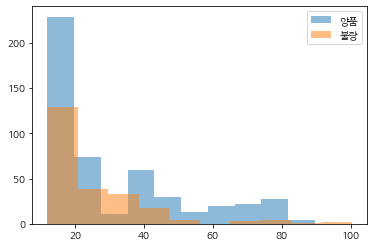

```python
def fun_plot_hist(data, var):
    plt.hist(data[data["SCALE"] == 0][var], label="양품", alpha=0.5)
    plt.hist(data[data["SCALE"] == 1][var], label="불량", alpha=0.5)
    plt.legend()# plate 두께
fun_plot_hist(df, "PT_THICK")
```

- 두께가 얇을수록 양품이 많다. 불량률도 높다.

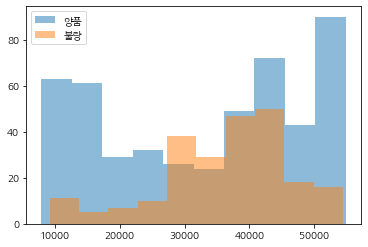

```python
fun_plot_hist(df,'PT_LENGTH')
```

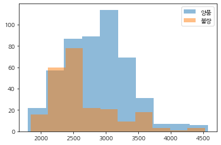

```python
fun_plot_hist(df,'PT_WIDTH')
```

- 작은 크기에서는 양품과 불량이 반반이다.
- 큰 크기에서는 불량률이 낮다.

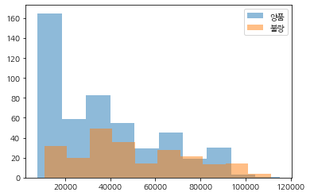

```python
fun_plot_hist(df,'PT_WEIGHT')
```

- 무게가 가벼운 경우, 양품의 비율이 높다.
- 무거운 경우, 불량의 비율이 높아진다.

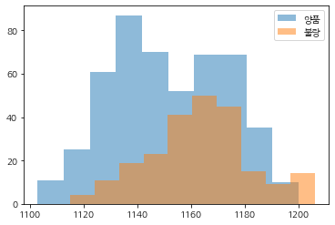

```python
fun_plot_hist(df,'FUR_HZ_TEMP')
```

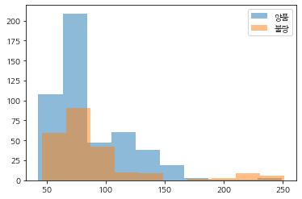

```python
fun_plot_hist(df,'FUR_HZ_TIME')
```

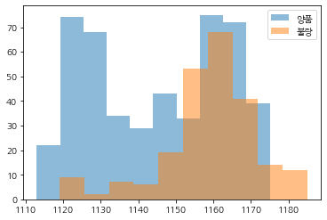

```python
fun_plot_hist(df,'FUR_SZ_TEMP')
```

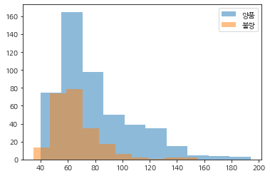

```python
fun_plot_hist(df,'FUR_SZ_TIME')
```

- 가열로 가열대 시간의 분포와 비슷하게 가열로 균열대 시간이 짧을수록 불량품이 많다.

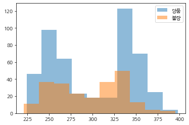

```python
fun_plot_hist(df,'FUR_TIME')
```

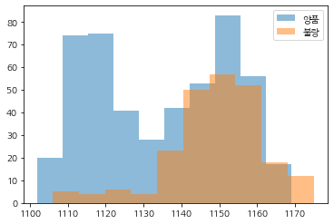

```python
fun_plot_hist(df,'FUR_EXTEMP')
```

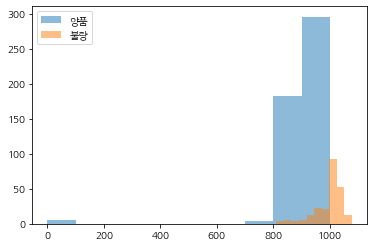

```python
fun_plot_hist(df,'ROLLING_TEMP_T5')
```

- 압연온도가 1000 이상일 때, 불량만 존재하였다.

### 이상치 처리

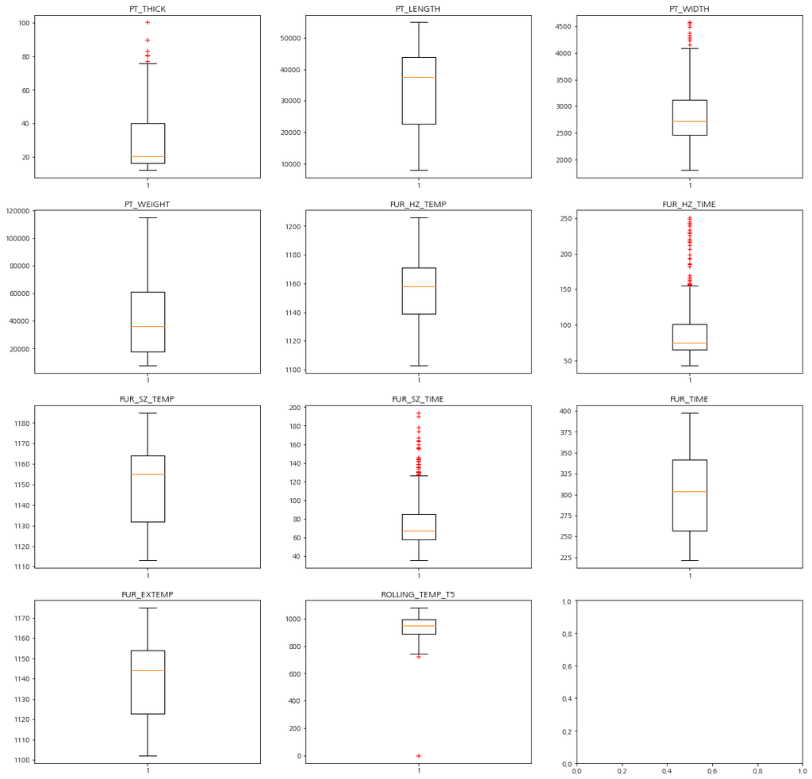

```python
fig,ax=plt.subplots(4,3,sharex=False,sharey=False)
fig.set_size_inches(20,20)
for i in range(len(numerical)):
    ax[i//3,i%3].boxplot(df[numerical[i]],sym="r+")
    ax[i//3,i%3].set_title(numerical[i])
```

```python
def outliers_iqr(data):
    q1,q3 = np.percentile(data,[25,75])
    iqr=q3-q1
    lower_bound=q1-(iqr*1.5)
    upper_bound=q3+(iqr*1.5)
    return np.where((data>upper_bound)|(data<lower_bound))
```

```python
ROLLING_TEMP_T5_outlier_index=outliers_iqr(df['ROLLING_TEMP_T5'])[0]
```

```python
ROLLING_TEMP_T5_outlier_index
```

```
array([ 41, 184, 185, 494, 495, 496, 519], dtype=int64)
```

```python
df.drop(ROLLING_TEMP_T5_outlier_index,axis=0,inplace=True)
```

```python
df
```

|  | SCALE | STEEL_KIND | PT_THICK | PT_WIDTH | PT_LENGTH | PT_WEIGHT | FUR_NO | FUR_NO_ROW | FUR_HZ_TEMP | FUR_HZ_TIME | FUR_SZ_TEMP | FUR_SZ_TIME | FUR_TIME | FUR_EXTEMP | ROLLING_TEMP_T5 | HSB | ROLLING_DESCALING | WORK_GR | spec_new |
| --- | --- | --- | --- | --- | --- | --- | --- | --- | --- | --- | --- | --- | --- | --- | --- | --- | --- | --- | --- |
| 0 | 0 | T1 | 32.25 | 3707 | 15109 | 14180 | 1호기 | 1열 | 1144 | 116 | 1133 | 59 | 282 | 1125 | 934 | 적용 | 8 | 2조 | 선체구조용강재 |
| 1 | 0 | T1 | 32.25 | 3707 | 15109 | 14180 | 1호기 | 2열 | 1144 | 122 | 1135 | 53 | 283 | 1120 | 937 | 적용 | 8 | 2조 | 선체구조용강재 |
| 2 | 0 | T8 | 33.27 | 3619 | 19181 | 18130 | 2호기 | 1열 | 1129 | 116 | 1121 | 55 | 282 | 1106 | 889 | 적용 | 8 | 3조 | 선체구조용강재 |
| 3 | 0 | T8 | 33.27 | 3619 | 19181 | 18130 | 2호기 | 2열 | 1152 | 125 | 1127 | 68 | 316 | 1113 | 885 | 적용 | 8 | 3조 | 선체구조용강재 |
| 4 | 0 | T8 | 38.33 | 3098 | 13334 | 12430 | 3호기 | 1열 | 1140 | 134 | 1128 | 48 | 314 | 1118 | 873 | 적용 | 8 | 1조 | 선체구조용강재 |
| ... | ... | ... | ... | ... | ... | ... | ... | ... | ... | ... | ... | ... | ... | ... | ... | ... | ... | ... | ... |
| 715 | 1 | C0 | 20.14 | 3580 | 38639 | 21870 | 3호기 | 1열 | 1172 | 72 | 1164 | 62 | 245 | 1155 | 1005 | 적용 | 8 | 2조 | 선체구조용강재 |
| 716 | 0 | C0 | 15.08 | 3212 | 48233 | 18340 | 2호기 | 1열 | 1150 | 61 | 1169 | 61 | 238 | 1160 | 947 | 적용 | 10 | 1조 | 선체구조용강재 |
| 717 | 0 | C0 | 16.60 | 3441 | 43688 | 19590 | 2호기 | 2열 | 1169 | 65 | 1163 | 77 | 247 | 1152 | 948 | 적용 | 10 | 4조 | 선체구조용강재 |
| 718 | 0 | C0 | 15.59 | 3363 | 48740 | 80240 | 3호기 | 2열 | 1179 | 86 | 1163 | 45 | 243 | 1154 | 940 | 적용 | 10 | 2조 | 선체구조용강재 |
| 719 | 0 | C0 | 16.09 | 3400 | 54209 | 69840 | 3호기 | 1열 | 1186 | 82 | 1169 | 45 | 239 | 1155 | 957 | 적용 | 10 | 2조 | 선체구조용강재 |

713 rows × 19 columns

### 상관계수

```python
numeric_corr=numeric.corr()
```

```python
numeric_corr
```

|  | PT_THICK | PT_LENGTH | PT_WIDTH | PT_WEIGHT | FUR_HZ_TEMP | FUR_HZ_TIME | FUR_SZ_TEMP | FUR_SZ_TIME | FUR_TIME | FUR_EXTEMP | ROLLING_TEMP_T5 |
| --- | --- | --- | --- | --- | --- | --- | --- | --- | --- | --- | --- |
| PT_THICK | 1.000000 | -0.862618 | -0.313151 | -0.397391 | -0.523926 | 0.171835 | -0.694770 | 0.269365 | 0.413009 | -0.687565 | -0.373976 |
| PT_LENGTH | -0.862618 | 1.000000 | 0.119726 | 0.451815 | 0.473111 | -0.090338 | 0.645402 | -0.230159 | -0.251950 | 0.641330 | 0.312762 |
| PT_WIDTH | -0.313151 | 0.119726 | 1.000000 | 0.031009 | 0.180024 | -0.126002 | 0.227296 | -0.051361 | -0.393200 | 0.216078 | -0.021807 |
| PT_WEIGHT | -0.397391 | 0.451815 | 0.031009 | 1.000000 | 0.153331 | 0.007292 | 0.359513 | -0.193112 | -0.057776 | 0.361377 | 0.263216 |
| FUR_HZ_TEMP | -0.523926 | 0.473111 | 0.180024 | 0.153331 | 1.000000 | -0.112438 | 0.772907 | -0.327912 | -0.348223 | 0.758185 | 0.265310 |
| FUR_HZ_TIME | 0.171835 | -0.090338 | -0.126002 | 0.007292 | -0.112438 | 1.000000 | -0.210175 | 0.067994 | 0.483407 | -0.196404 | 0.010149 |
| FUR_SZ_TEMP | -0.694770 | 0.645402 | 0.227296 | 0.359513 | 0.772907 | -0.210175 | 1.000000 | -0.566177 | -0.477177 | 0.985245 | 0.452297 |
| FUR_SZ_TIME | 0.269365 | -0.230159 | -0.051361 | -0.193112 | -0.327912 | 0.067994 | -0.566177 | 1.000000 | 0.490728 | -0.565912 | -0.268844 |
| FUR_TIME | 0.413009 | -0.251950 | -0.393200 | -0.057776 | -0.348223 | 0.483407 | -0.477177 | 0.490728 | 1.000000 | -0.467894 | -0.199352 |
| FUR_EXTEMP | -0.687565 | 0.641330 | 0.216078 | 0.361377 | 0.758185 | -0.196404 | 0.985245 | -0.565912 | -0.467894 | 1.000000 | 0.441226 |
| ROLLING_TEMP_T5 | -0.373976 | 0.312762 | -0.021807 | 0.263216 | 0.265310 | 0.010149 | 0.452297 | -0.268844 | -0.199352 | 0.441226 | 1.000000 |

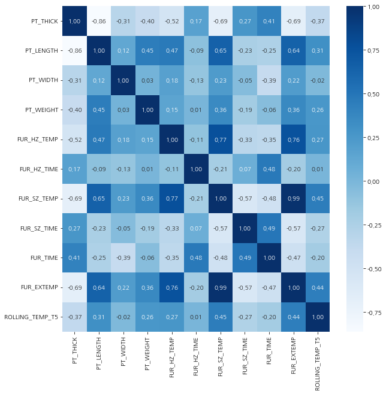

```python
fig , ax = plt.subplots(figsize=(10,10))
sns.heatmap(numeric_corr,annot=True,fmt=".2f",cmap = "Blues", ax=ax)
plt.show()
```

```python
df.drop(['FUR_EXTEMP'],axis=1,inplace=True)
```

### VF 찾기

```python
def fun_print_crosstab(data,var):
    print(pd.crosstab(index=data["SCALE"],columns=data[var]))
    print()
    print(pd.crosstab(index=data["SCALE"],columns=data[var],normalize="columns").round(3))
```

```python
fun_print_crosstab(df,"STEEL_KIND")
```

```
STEEL_KIND   C0  C1  C3  T0  T1  T3  T5  T7  T8
SCALE
0           288   0   6  13  16   2  39  29  89
1           212   1   1   2   2   0   2   6   5

STEEL_KIND     C0   C1     C3     T0     T1   T3     T5     T7     T8
SCALE
0           0.576  0.0  0.857  0.867  0.889  1.0  0.951  0.829  0.947
1           0.424  1.0  0.143  0.133  0.111  0.0  0.049  0.171  0.053
```

```python
fun_print_crosstab(df,"spec_new")
```

```
spec_new  교량구조용강재  구조용압연강재  보일러및압력용기용강재  석유수송용강재  선체구조용강재  일반재
SCALE
0               4      115            4        2      331   26
1               0      119            2        0      108    2

spec_new  교량구조용강재  구조용압연강재  보일러및압력용기용강재  석유수송용강재  선체구조용강재    일반재
SCALE
0             1.0    0.491        0.667      1.0    0.754  0.929
1             0.0    0.509        0.333      0.0    0.246  0.071
```

```python
fun_print_crosstab(df,"WORK_GR")
```

```
WORK_GR   1조   2조   3조   4조
SCALE
0        121  119  114  128
1         67   45   54   65

WORK_GR     1조     2조     3조     4조
SCALE
0        0.644  0.726  0.679  0.663
1        0.356  0.274  0.321  0.337
```

```python
fun_print_crosstab(df,"FUR_NO")
```

```
FUR_NO  1호기  2호기  3호기
SCALE
0       166  165  151
1        73   70   88

FUR_NO    1호기    2호기    3호기
SCALE
0       0.695  0.702  0.632
1       0.305  0.298  0.368
```

```python
fun_print_crosstab(df,"FUR_NO_ROW")
```

```
FUR_NO_ROW   1열   2열
SCALE
0           239  243
1           120  111

FUR_NO_ROW     1열     2열
SCALE
0           0.666  0.686
1           0.334  0.314
```

```python
fun_print_crosstab(df,"HSB")
```

```
HSB    미적용   적용
SCALE
0        0  482
1       33  198

HSB    미적용     적용
SCALE
0      0.0  0.709
1      1.0  0.291
```

- 크로스 탭을 그려본 결과, FUR_NO_ROW, FUR_NO, WORK_GR 별로 불량율이 비슷하다고 판단하여, SCALE에 영향을 주지 않는 요인으로 판단하여 제거하기로 하였다.

```python
df.drop(['FUR_NO_ROW','FUR_NO','WORK_GR'],axis=1,inplace=True)
```

```python
df
```

|  | SCALE | STEEL_KIND | PT_THICK | PT_WIDTH | PT_LENGTH | PT_WEIGHT | FUR_HZ_TEMP | FUR_HZ_TIME | FUR_SZ_TEMP | FUR_SZ_TIME | FUR_TIME | ROLLING_TEMP_T5 | HSB | ROLLING_DESCALING | spec_new |
| --- | --- | --- | --- | --- | --- | --- | --- | --- | --- | --- | --- | --- | --- | --- | --- |
| 0 | 0 | T1 | 32.25 | 3707 | 15109 | 14180 | 1144 | 116 | 1133 | 59 | 282 | 934 | 적용 | 8 | 선체구조용강재 |
| 1 | 0 | T1 | 32.25 | 3707 | 15109 | 14180 | 1144 | 122 | 1135 | 53 | 283 | 937 | 적용 | 8 | 선체구조용강재 |
| 2 | 0 | T8 | 33.27 | 3619 | 19181 | 18130 | 1129 | 116 | 1121 | 55 | 282 | 889 | 적용 | 8 | 선체구조용강재 |
| 3 | 0 | T8 | 33.27 | 3619 | 19181 | 18130 | 1152 | 125 | 1127 | 68 | 316 | 885 | 적용 | 8 | 선체구조용강재 |
| 4 | 0 | T8 | 38.33 | 3098 | 13334 | 12430 | 1140 | 134 | 1128 | 48 | 314 | 873 | 적용 | 8 | 선체구조용강재 |
| ... | ... | ... | ... | ... | ... | ... | ... | ... | ... | ... | ... | ... | ... | ... | ... |
| 715 | 1 | C0 | 20.14 | 3580 | 38639 | 21870 | 1172 | 72 | 1164 | 62 | 245 | 1005 | 적용 | 8 | 선체구조용강재 |
| 716 | 0 | C0 | 15.08 | 3212 | 48233 | 18340 | 1150 | 61 | 1169 | 61 | 238 | 947 | 적용 | 10 | 선체구조용강재 |
| 717 | 0 | C0 | 16.60 | 3441 | 43688 | 19590 | 1169 | 65 | 1163 | 77 | 247 | 948 | 적용 | 10 | 선체구조용강재 |
| 718 | 0 | C0 | 15.59 | 3363 | 48740 | 80240 | 1179 | 86 | 1163 | 45 | 243 | 940 | 적용 | 10 | 선체구조용강재 |
| 719 | 0 | C0 | 16.09 | 3400 | 54209 | 69840 | 1186 | 82 | 1169 | 45 | 239 | 957 | 적용 | 10 | 선체구조용강재 |

713 rows × 15 columns

### 더미 데이터

```python
df_dummy=pd.get_dummies(df)
```

```python
df_dummy
```

|  | SCALE | PT_THICK | PT_WIDTH | PT_LENGTH | PT_WEIGHT | FUR_HZ_TEMP | FUR_HZ_TIME | FUR_SZ_TEMP | FUR_SZ_TIME | FUR_TIME | ... | STEEL_KIND_T7 | STEEL_KIND_T8 | HSB_미적용 | HSB_적용 | spec_new_교량구조용강재 | spec_new_구조용압연강재 | spec_new_보일러및압력용기용강재 | spec_new_석유수송용강재 | spec_new_선체구조용강재 | spec_new_일반재 |
| --- | --- | --- | --- | --- | --- | --- | --- | --- | --- | --- | --- | --- | --- | --- | --- | --- | --- | --- | --- | --- | --- |
| 0 | 0 | 32.25 | 3707 | 15109 | 14180 | 1144 | 116 | 1133 | 59 | 282 | ... | 0 | 0 | 0 | 1 | 0 | 0 | 0 | 0 | 1 | 0 |
| 1 | 0 | 32.25 | 3707 | 15109 | 14180 | 1144 | 122 | 1135 | 53 | 283 | ... | 0 | 0 | 0 | 1 | 0 | 0 | 0 | 0 | 1 | 0 |
| 2 | 0 | 33.27 | 3619 | 19181 | 18130 | 1129 | 116 | 1121 | 55 | 282 | ... | 0 | 1 | 0 | 1 | 0 | 0 | 0 | 0 | 1 | 0 |
| 3 | 0 | 33.27 | 3619 | 19181 | 18130 | 1152 | 125 | 1127 | 68 | 316 | ... | 0 | 1 | 0 | 1 | 0 | 0 | 0 | 0 | 1 | 0 |
| 4 | 0 | 38.33 | 3098 | 13334 | 12430 | 1140 | 134 | 1128 | 48 | 314 | ... | 0 | 1 | 0 | 1 | 0 | 0 | 0 | 0 | 1 | 0 |
| ... | ... | ... | ... | ... | ... | ... | ... | ... | ... | ... | ... | ... | ... | ... | ... | ... | ... | ... | ... | ... | ... |
| 715 | 1 | 20.14 | 3580 | 38639 | 21870 | 1172 | 72 | 1164 | 62 | 245 | ... | 0 | 0 | 0 | 1 | 0 | 0 | 0 | 0 | 1 | 0 |
| 716 | 0 | 15.08 | 3212 | 48233 | 18340 | 1150 | 61 | 1169 | 61 | 238 | ... | 0 | 0 | 0 | 1 | 0 | 0 | 0 | 0 | 1 | 0 |
| 717 | 0 | 16.60 | 3441 | 43688 | 19590 | 1169 | 65 | 1163 | 77 | 247 | ... | 0 | 0 | 0 | 1 | 0 | 0 | 0 | 0 | 1 | 0 |
| 718 | 0 | 15.59 | 3363 | 48740 | 80240 | 1179 | 86 | 1163 | 45 | 243 | ... | 0 | 0 | 0 | 1 | 0 | 0 | 0 | 0 | 1 | 0 |
| 719 | 0 | 16.09 | 3400 | 54209 | 69840 | 1186 | 82 | 1169 | 45 | 239 | ... | 0 | 0 | 0 | 1 | 0 | 0 | 0 | 0 | 1 | 0 |

713 rows × 29 columns

```python
df_x = df_dummy.drop("SCALE", axis = 1, inplace= False)
df_y = df_dummy["SCALE"]
```

## VF 찾기

```python
df_x
```

|  | PT_THICK | PT_WIDTH | PT_LENGTH | PT_WEIGHT | FUR_HZ_TEMP | FUR_HZ_TIME | FUR_SZ_TEMP | FUR_SZ_TIME | FUR_TIME | ROLLING_TEMP_T5 | ... | STEEL_KIND_T7 | STEEL_KIND_T8 | HSB_미적용 | HSB_적용 | spec_new_교량구조용강재 | spec_new_구조용압연강재 | spec_new_보일러및압력용기용강재 | spec_new_석유수송용강재 | spec_new_선체구조용강재 | spec_new_일반재 |
| --- | --- | --- | --- | --- | --- | --- | --- | --- | --- | --- | --- | --- | --- | --- | --- | --- | --- | --- | --- | --- | --- |
| 0 | 32.25 | 3707 | 15109 | 14180 | 1144 | 116 | 1133 | 59 | 282 | 934 | ... | 0 | 0 | 0 | 1 | 0 | 0 | 0 | 0 | 1 | 0 |
| 1 | 32.25 | 3707 | 15109 | 14180 | 1144 | 122 | 1135 | 53 | 283 | 937 | ... | 0 | 0 | 0 | 1 | 0 | 0 | 0 | 0 | 1 | 0 |
| 2 | 33.27 | 3619 | 19181 | 18130 | 1129 | 116 | 1121 | 55 | 282 | 889 | ... | 0 | 1 | 0 | 1 | 0 | 0 | 0 | 0 | 1 | 0 |
| 3 | 33.27 | 3619 | 19181 | 18130 | 1152 | 125 | 1127 | 68 | 316 | 885 | ... | 0 | 1 | 0 | 1 | 0 | 0 | 0 | 0 | 1 | 0 |
| 4 | 38.33 | 3098 | 13334 | 12430 | 1140 | 134 | 1128 | 48 | 314 | 873 | ... | 0 | 1 | 0 | 1 | 0 | 0 | 0 | 0 | 1 | 0 |
| ... | ... | ... | ... | ... | ... | ... | ... | ... | ... | ... | ... | ... | ... | ... | ... | ... | ... | ... | ... | ... | ... |
| 715 | 20.14 | 3580 | 38639 | 21870 | 1172 | 72 | 1164 | 62 | 245 | 1005 | ... | 0 | 0 | 0 | 1 | 0 | 0 | 0 | 0 | 1 | 0 |
| 716 | 15.08 | 3212 | 48233 | 18340 | 1150 | 61 | 1169 | 61 | 238 | 947 | ... | 0 | 0 | 0 | 1 | 0 | 0 | 0 | 0 | 1 | 0 |
| 717 | 16.60 | 3441 | 43688 | 19590 | 1169 | 65 | 1163 | 77 | 247 | 948 | ... | 0 | 0 | 0 | 1 | 0 | 0 | 0 | 0 | 1 | 0 |
| 718 | 15.59 | 3363 | 48740 | 80240 | 1179 | 86 | 1163 | 45 | 243 | 940 | ... | 0 | 0 | 0 | 1 | 0 | 0 | 0 | 0 | 1 | 0 |
| 719 | 16.09 | 3400 | 54209 | 69840 | 1186 | 82 | 1169 | 45 | 239 | 957 | ... | 0 | 0 | 0 | 1 | 0 | 0 | 0 | 0 | 1 | 0 |

713 rows × 28 columns

```python
df_y
```

```
0      0
1      0
2      0
3      0
4      0
      ..
715    1
716    0
717    0
718    0
719    0
Name: SCALE, Length: 713, dtype: int64
```

```python
df_train_x, df_test_x, df_train_y, df_test_y = train_test_split(df_x, df_y, test_size= 0.3)
print("분할 전 설명변수 데이터: ", df_x.shape)
print("분할 후 설명변수 데이터: Train", df_train_x.shape, "Test", df_test_x.shape)
```

```
분할 전 설명변수 데이터:  (713, 28)
분할 후 설명변수 데이터: Train (499, 28) Test (214, 28)
```

### 의사결정나무 기본모델

```python
#기본 옵션으로 모델 생성
tree_uncustomized = DecisionTreeClassifier()
tree_uncustomized.fit(df_train_x,df_train_y)

#train 데이터 정확도
print("Accuracy on training set: {:.3f}".format(tree_uncustomized.score(df_train_x,df_train_y)))

#test 데이터 정확도
print("Accuracy on test set: {:.3f}".format(tree_uncustomized.score(df_test_x,df_test_y)))
```

```
Accuracy on training set: 1.000
Accuracy on test set: 0.949
```

```python
# 변수명
v_feature_name = df_train_x.columns

# tree.feature_importance_로 설명변수 중요도 확인 및 테이블로 저장
df_importance = pd.DataFrame()
df_importance["Feature"] = v_feature_name
df_importance["Importance"] = tree_uncustomized.feature_importances_

# df_feature_importance의 테이블을 중요도 순으로 정렬
df_importance.sort_values("Importance", ascending=False, inplace=True)
df_importance.round(3)### 모델 생성
```

|  | Feature | Importance |
| --- | --- | --- |
| 9 | ROLLING_TEMP_T5 | 0.575 |
| 21 | HSB_적용 | 0.158 |
| 6 | FUR_SZ_TEMP | 0.135 |
| 10 | ROLLING_DESCALING | 0.057 |
| 3 | PT_WEIGHT | 0.018 |
| 5 | FUR_HZ_TIME | 0.018 |
| 7 | FUR_SZ_TIME | 0.012 |
| 8 | FUR_TIME | 0.011 |
| 1 | PT_WIDTH | 0.011 |
| 14 | STEEL_KIND_T0 | 0.004 |
| 18 | STEEL_KIND_T7 | 0.000 |
| 24 | spec_new_보일러및압력용기용강재 | 0.000 |
| 23 | spec_new_구조용압연강재 | 0.000 |
| 22 | spec_new_교량구조용강재 | 0.000 |
| 25 | spec_new_석유수송용강재 | 0.000 |
| 26 | spec_new_선체구조용강재 | 0.000 |
| 20 | HSB_미적용 | 0.000 |
| 19 | STEEL_KIND_T8 | 0.000 |
| 0 | PT_THICK | 0.000 |
| 17 | STEEL_KIND_T5 | 0.000 |
| 16 | STEEL_KIND_T3 | 0.000 |
| 15 | STEEL_KIND_T1 | 0.000 |
| 13 | STEEL_KIND_C3 | 0.000 |
| 12 | STEEL_KIND_C1 | 0.000 |
| 11 | STEEL_KIND_C0 | 0.000 |
| 4 | FUR_HZ_TEMP | 0.000 |
| 2 | PT_LENGTH | 0.000 |
| 27 | spec_new_일반재 | 0.000 |

### 랜덤포레스트 기본모델

```python
#기본 옵션으로 모델 생성
rf_uncustomized = RandomForestClassifier()
rf_uncustomized.fit(df_train_x, df_train_y)

# Train, Test 데이터 정확도
print("Score on training set: {:.3f}".format(rf_uncustomized.score(df_train_x, df_train_y)))
print("Score on test set: {:.3f}".format(rf_uncustomized.score(df_test_x, df_test_y)))
```

```
Score on training set: 1.000
Score on test set: 0.949
```

```python
# 변수명
v_feature_name = df_train_x.columns

# tree.feature_importance_로 설명변수 중요도 확인 및 테이블로 저장
df_importance = pd.DataFrame()
df_importance["Feature"] = v_feature_name
df_importance["Importance"] = rf_uncustomized.feature_importances_

# df_feature_importance의 테이블을 중요도 순으로 정렬
df_importance.sort_values("Importance", ascending=False, inplace=True)
df_importance.round(3)### 모델 생성
```

|  | Feature | Importance |
| --- | --- | --- |
| 9 | ROLLING_TEMP_T5 | 0.344 |
| 6 | FUR_SZ_TEMP | 0.096 |
| 1 | PT_WIDTH | 0.071 |
| 21 | HSB_적용 | 0.065 |
| 10 | ROLLING_DESCALING | 0.056 |
| 4 | FUR_HZ_TEMP | 0.056 |
| 20 | HSB_미적용 | 0.050 |
| 0 | PT_THICK | 0.044 |
| 2 | PT_LENGTH | 0.043 |
| 8 | FUR_TIME | 0.038 |
| 7 | FUR_SZ_TIME | 0.035 |
| 3 | PT_WEIGHT | 0.034 |
| 5 | FUR_HZ_TIME | 0.024 |
| 11 | STEEL_KIND_C0 | 0.023 |
| 23 | spec_new_구조용압연강재 | 0.009 |
| 26 | spec_new_선체구조용강재 | 0.004 |
| 18 | STEEL_KIND_T7 | 0.002 |
| 14 | STEEL_KIND_T0 | 0.001 |
| 24 | spec_new_보일러및압력용기용강재 | 0.001 |
| 19 | STEEL_KIND_T8 | 0.001 |
| 15 | STEEL_KIND_T1 | 0.001 |
| 17 | STEEL_KIND_T5 | 0.001 |
| 27 | spec_new_일반재 | 0.001 |
| 13 | STEEL_KIND_C3 | 0.001 |
| 22 | spec_new_교량구조용강재 | 0.000 |
| 12 | STEEL_KIND_C1 | 0.000 |
| 25 | spec_new_석유수송용강재 | 0.000 |
| 16 | STEEL_KIND_T3 | 0.000 |

### 그래디언트 부스팅 기본모델

```python
gb_uncustomized = GradientBoostingClassifier()
gb_uncustomized.fit(df_train_x, df_train_y)

# Train, Test 데이터 설명력
print("Score on training set: {:.3f}".format(gb_uncustomized.score(df_train_x, df_train_y)))
print("Score on test set: {:.3f}".format(gb_uncustomized.score(df_test_x, df_test_y)))
```

```
Score on training set: 1.000
Score on test set: 0.977
```

```python
# 변수명
v_feature_name = df_train_x.columns

# tree.feature_importance_로 설명변수 중요도 확인 및 테이블로 저장
df_importance = pd.DataFrame()
df_importance["Feature"] = v_feature_name
df_importance["Importance"] = rf_uncustomized.feature_importances_

# df_feature_importance의 테이블을 중요도 순으로 정렬
df_importance.sort_values("Importance", ascending=False, inplace=True)
df_importance.round(3)### 모델 생성
```

[output not shown]

- importance가 낮은 것 삭제

```python
df_train_x = df_train_x.drop(columns=["STEEL_KIND_T7", "spec_new_교량구조용강재", "spec_new_석유수송용강재",
                                       "STEEL_KIND_C1", "STEEL_KIND_T3", "spec_new_일반재", "STEEL_KIND_T1", "STEEL_KIND_C3"], axis=1)
df_test_x = df_test_x.drop(columns=["STEEL_KIND_T7", "spec_new_교량구조용강재", "spec_new_석유수송용강재",
                                       "STEEL_KIND_C1", "STEEL_KIND_T3", "spec_new_일반재", "STEEL_KIND_T1", "STEEL_KIND_C3"], axis=1)
```

## 로지스틱 회귀분석

```python
from sklearn.linear_model import LogisticRegression
classifier = LogisticRegression() # 특정변수 연관성이 강할때 penalty
classifier.fit(df_train_x, df_train_y)
# predicting test set
y_pred = classifier.predict(df_test_x)
accuracy_score(df_test_y, y_pred)
```

```
0.794392523364486
```